# R for Data Science: Import, Tidy, Transform, Visualize and Model Data

[figure not shown]

Capa do Livro

Livro em versão WEB: [R for Data Science](https://r4ds.had.co.nz/)

Pacotes importantes

```r
# Base de dados usado
#install.packages("data.table")

# ggplot2, tibble, tidyr, readr, purrr and dplyr.
#install.packages("tidyverse")
library(tidyverse)

# Complementam o tidyverse
#install.packages(c("nycflights13", "gapminder", "Lahman"))

# Ver as mensagens de erro em inglês
Sys.setenv(LANGUAGE = "en")
```

3.2 First Steps

3.2.1 The mpg data frame

```r
# Banco de dados
mpg <- ggplot2::mpg
```

3.2.2 Creating a ggplot

Plotando o mpg, displ no eixo x e hwy no eixo y.

ggplot() é formado em camadas, ggplot(data = mpg) cria um gráfico vazio, geom_point adiciona uma camada com gráfico de pontos. Os argumentos aes(x,y) definem as variaveis dos gráficos.

```r
 ggplot(data = mpg) +
  geom_point(mapping =  aes(x = displ, y = hwy))
```

[output not shown]

3.2.3 Modelo de ggplot

3.3 Aesthetic mappings

É possivel adicionar mais uma variável a um gráfico. Usando como exemplo o banco de dados eu posso definir um tipo de ponto ou cor diferente para cada tipo de carro.

```r
ggplot(data = mpg) +
  geom_point(mapping = aes(x = displ, y = hwy, color = class))
```

[output not shown]

Para colorir apenas uma varíavel é possivel associando o nome da aesthetic ao nome da variável interna aes().

Plotando com o aumento do tamanho na escala

```r
ggplot(data = mpg) + geom_point(mapping = aes(x = displ, y = hwy, size = class))
```

[output not shown]

Plotando usando a transparência

```r
# Left
ggplot(data = mpg) +
  geom_point(mapping = aes(x = displ, y = hwy, alpha = class))
```

[output not shown]

e o desenho dos pontos

```r
# Right
ggplot(data = mpg) +
  geom_point(mapping = aes(x = displ, y = hwy, shape = class))
```

[output not shown]

A sintaxe destaca um insight útil sobre xe y: as localizações xey de um ponto são estéticas, propriedades visuais que você pode mapear para variáveis para exibir informações sobre os dados.

```r
ggplot(data = mpg) +
  geom_point(mapping = aes(x = displ, y = hwy), color = "red")
```

[output not shown]

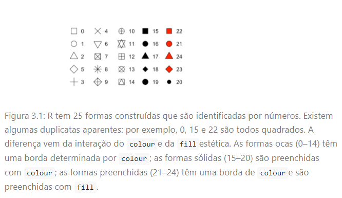

Formas dos pontos